# Parameters estimation for calibration

Simon Jean

2023-05-11

# I. Demand estimation

## A. Preliminary analysis : descriptive stats

First, look at the evolution of average weight per year :

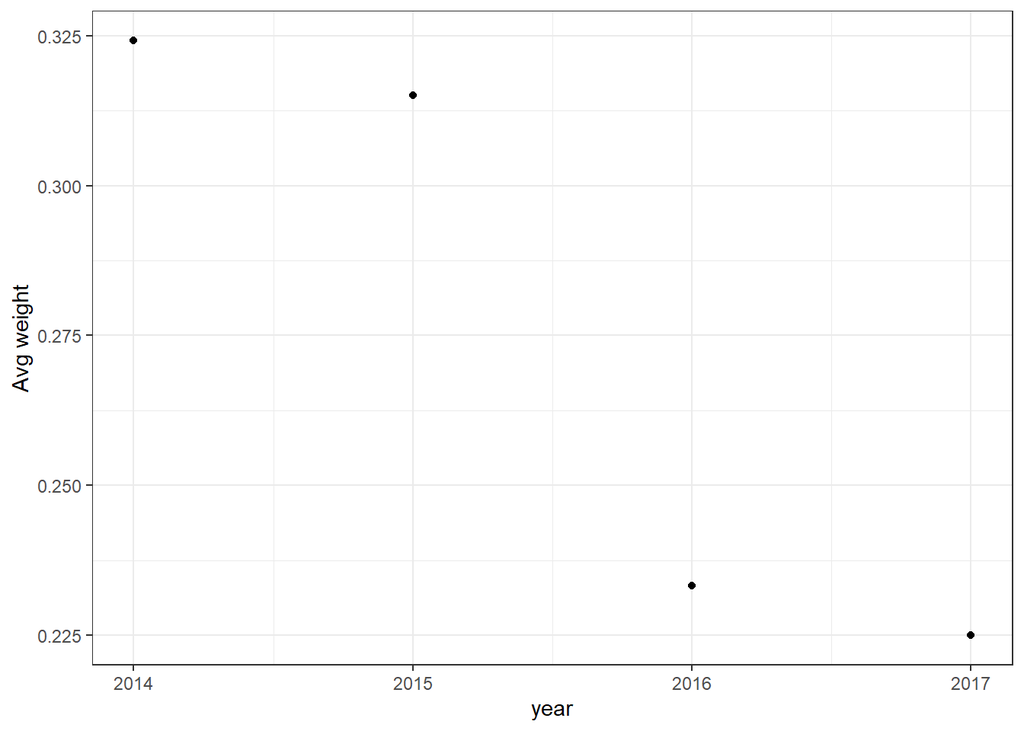

Observe a decrease of average weight. Second, look at the evolution of price per buche through time. To do so, I compute the product of `p` and `g` (price/gram * grams of buche).

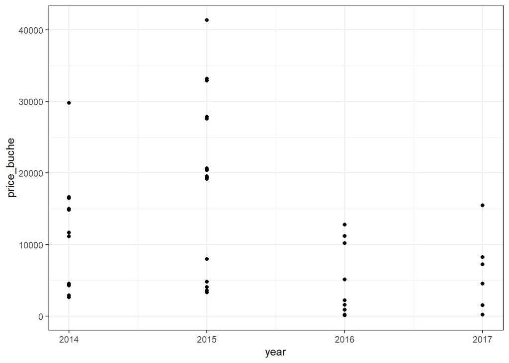

1. Variance of prices decreases with time
2. Average decreases

Conclusion : it seems like the market has evolved. It is hard to say whether (i) there was a crackdown a decrease in demand or (ii) supply increased.

That goes along with what follows : the catch has increased for years we have data for :

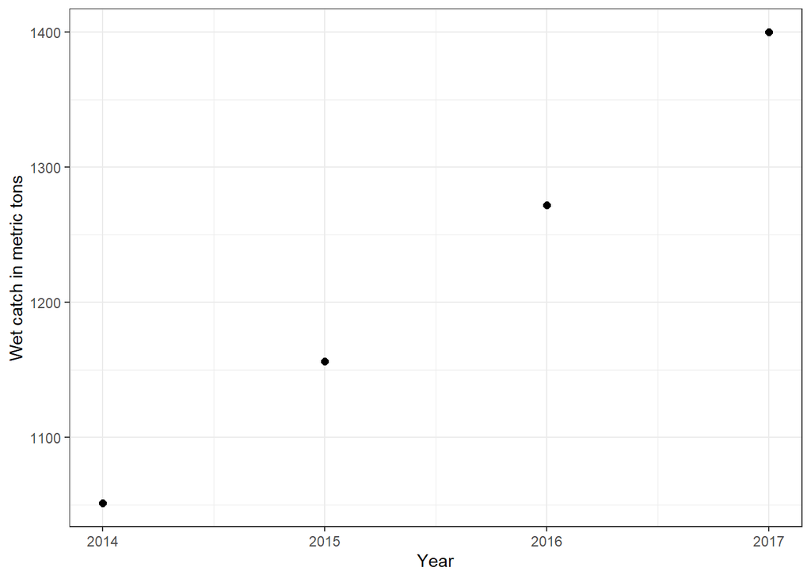

## B. Data reformating

First, recover individual totoaba poached from dried buche data. To do so:

1. `q` in `dat_p` is dried totoaba buche in tonnes : q*1000 is tonnes of dried totoaba buche
2. Given that we assume uniform distribution of totoaba size and that 1 totoaba = 500g of dried totoaba dried totoaba in kilos / 0.5 kilos -> Number of totoaba
3. Compare that to catch data :
- In `dat_p`, take `c` catch data in metric tonnes and convert to kilos (`c*1000`)
- Under the assumption of uniform distribution of size of caught totoaba, all weigh 25.7 kg (divide catch in kilos by average weight)

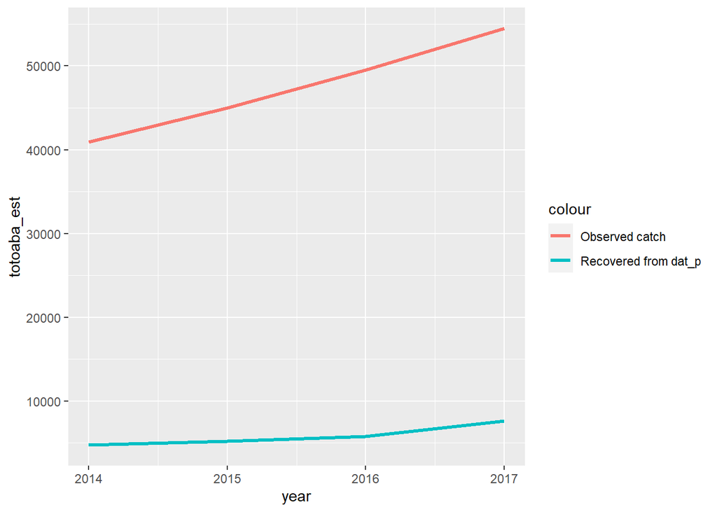

There is a big difference between estimates! Maybe it makes more sense to use price data per buche and observed catch.

### C. Attempt 1 : use price per totoaba and variation in realized catch

In what follows :

- I use the variations in price per totoaba calculated as `price_per_totoaba = p*g` from `dat_p`.
- I use the variations in realized catch from `dat_bc`, converted to totoaba individuals assuming uniform weight distribution (`tototaba = c*1000/25.7`)

```
##
## Call:
## lm(formula = price_buche ~ totoaba, data = new_dat)
##
## Residuals:
##    Min     1Q Median     3Q    Max
## -13448  -8545  -1059   6302  28103
##
## Coefficients:
##               Estimate Std. Error t value Pr(>|t|)
## (Intercept) 44321.7293 15723.3226   2.819  0.00726 **
## totoaba        -0.6910     0.3398  -2.033  0.04820 *
## ---
## Signif. codes:  0 '***' 0.001 '**' 0.01 '*' 0.05 '.' 0.1 ' ' 1
##
## Residual standard error: 10040 on 43 degrees of freedom
## Multiple R-squared:  0.08773,    Adjusted R-squared:  0.06651
## F-statistic: 4.135 on 1 and 43 DF,  p-value: 0.0482
```

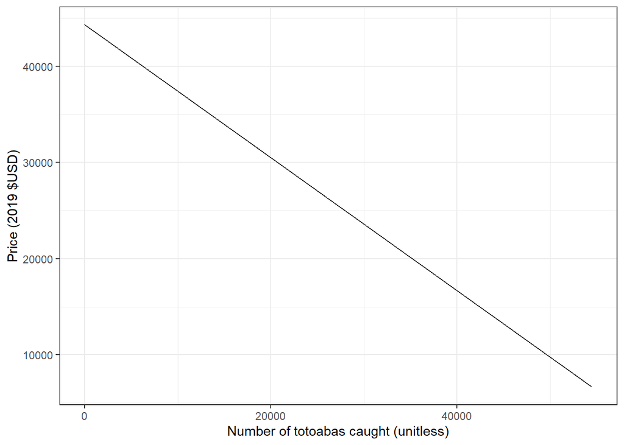

### D. Attempt 2 : Use price per totoaba and variation in estimated catch (converting dried buche tons to live totoaba)

Just to make sure we have results that are not too weird, I regress price on estimated catch.

```
##
## Call:
## lm(formula = price_buche ~ totoaba, data = new_dat)
##
## Residuals:
##      Min       1Q   Median       3Q      Max
## -12533.7  -9457.1   -438.2   6024.3  27824.7
##
## Coefficients:
##              Estimate Std. Error t value Pr(>|t|)
## (Intercept) 31249.550   9428.206   3.314  0.00187 **
## totoaba        -3.397      1.686  -2.015  0.05019 .
## ---
## Signif. codes:  0 '***' 0.001 '**' 0.01 '*' 0.05 '.' 0.1 ' ' 1
##
## Residual standard error: 10040 on 43 degrees of freedom
## Multiple R-squared:  0.08627,    Adjusted R-squared:  0.06502
## F-statistic:  4.06 on 1 and 43 DF,  p-value: 0.05019
```

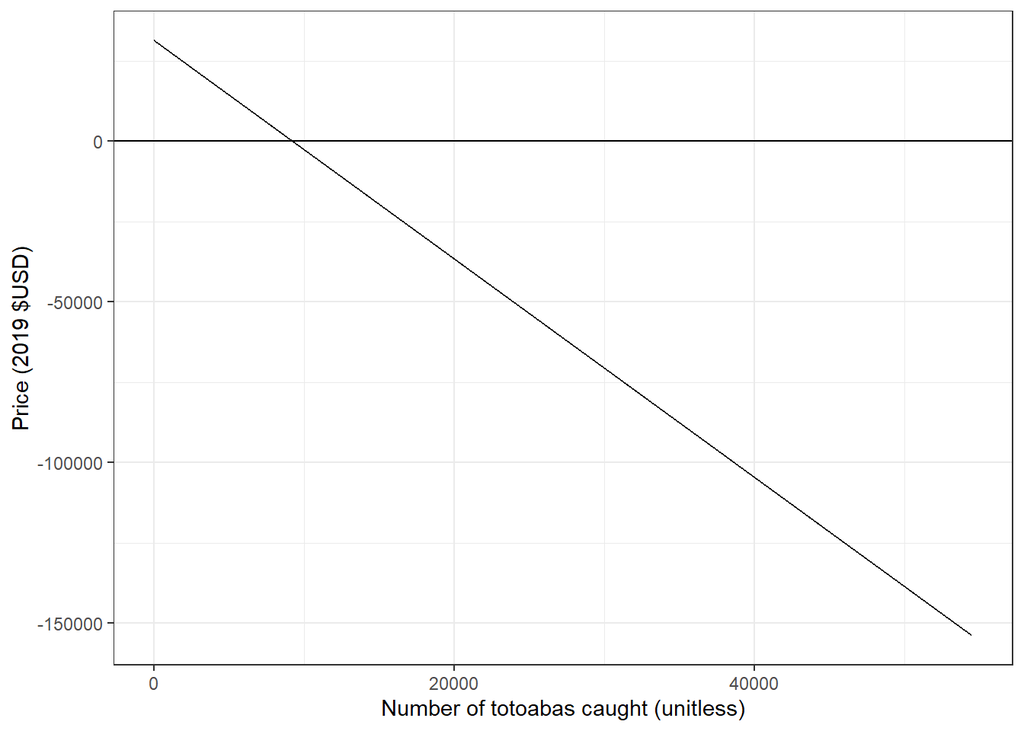

In the end, we get two demand models :

```
##   Intercept (alpha)       beta
## 1          44321.73 -0.6910223
## 2          31249.55 -3.3970189
```

We keep the first model as it seems more pertinent.